# MetabolomicsPipeline-vignette

Joel Parker

05/31/2024

# Contents

## 1 Installation

You can install the MetabolomicsPipeline package directly from BioConductor using the following code. Note, this package is not yet available on BioConductor.

```r
if (!requireNamespace("BiocManager", quietly = TRUE)) {
    install.packages("BiocManager")
}
BiocManager::install("MetabolomicsPipeline", force = TRUE)
```

You can additionally install the current version which is hosted on github using the following code.

```r
if (!requireNamespace("devtools", quietly=TRUE))
    install.packages("devtools")

 devtools::install_github("datalifecycle-ua/MetabolomicsPipeline", build_vignettes = TRUE)
```

Once the MetabolomicsPipeline package is installed, we can load it into the environment. Note we are also loading the “table1” package. This package is not required by the MetabolomicPipeline, however, the table1 package contains great functions for creating tables. Specifically, it is useful for showing the number of samples in each of our experimental groups. We recommend installing this package using install.packages(“table1”). The “SummarizedExperiment” and “ggplot2” packages are required to install the MetabolomicsPipeline package and will being automatically installed (if not already installed) when installing the MetabolomicsPipline package using the commands above.

```r
knitr::opts_chunk$set(
    collapse = TRUE,
    comment = "#>",
    fig.width = 10,
    fig.height = 10
)

# Tables
library(table1)
# Load Metabolomics Pipeline
library(MetabolomicsPipeline)

library(SummarizedExperiment)
# Figures
library(ggplot2)
```

## 2 Introduction

The purpose of the MetabolomicPipeline package is to streamline the analysis for metabolomics experiments. In this vignette we demonstrate how to use MetabolomicsPipeline package for:

- Data Processing
- Exploratory Analysis
- Subpathway Analysis
- Metabolite pairwise comparisons
- Subpathway box plots and line plots

### 2.1 Data Description

In this vignette, we will use data which consists of 86 samples (42 males, 44 females), three treatment groups, and the samples were taken at three different time points.

### 2.2 Metabolomics data as a SummarizedExperiment

Metabolomics experiments leverage multiple data tables for analysis. The datasets needed for the downstream analysis are:

1.) Sample metadata

2.) Chemical annotation

3.) Peak data (samples x rows).

### 2.3 Data loading

The MetabolomicsPipeline package provides a convenient way to load each of these datasets together as a [SummarizedExperiment](https://bioconductor.org/packages/release/bioc/vignettes/SummarizedExperiment/inst/doc/SummarizedExperiment.html) using create_met_se(). In this chunk we load the demo sample metadata, chemical annotation, and peak data into a SummarizedExperiment.

1. load the demo sample metadata, chemical annotation, and peak data into a SummarizedExperiment.
2. Create a table of the sample distribution

```r
################################################################################
### Load Data ##################################################################
################################################################################

# if sample metadata, chemical annotation and peak data are stored in .xlsx
# you can use.

# dat <- load_met_excel(
  # path,
  # raw_sheet = "Peak Area Data",
  # chemical_sheet = "Chemical Annotation",
  # sample_meta = "Sample Meta Data",
  # normalized_peak = "Log Transformed Data",
  # sample_names = "PARENT_SAMPLE_NAME",
  # chemicalID = "CHEM_ID"
# )

# Get demo sample metadata
data("demoSampleMeta", package = "MetabolomicsPipeline")

# Get demo chemical annotation file
data("demoChemAnno", package = "MetabolomicsPipeline")

# Get demo peak data
data("demoPeak", package = "MetabolomicsPipeline")

dat <- createMetSe(chemical_annotation = demoChemAnno,
                     sample_metadata = demoSampleMeta,
                     peak_data = demoPeak,
                     chemical_id = "CHEM_ID",
                     sample_names = "PARENT_SAMPLE_NAME")


################################################################################
### Create Table 1 #############################################################
################################################################################
# Create table 1
tbl1 <- table1(~ GROUP_NAME + TIME1 | Gender,
  data = colData(dat)
)

# Display table 1
tbl1
```

|  | Female (N=44) | Male (N=42) | Overall (N=86) |
| --- | --- | --- | --- |
| GROUP_NAME |  |  |  |
| Control | 14 (31.8%) | 14 (33.3%) | 28 (32.6%) |
| treat1 | 15 (34.1%) | 14 (33.3%) | 29 (33.7%) |
| treat2 | 15 (34.1%) | 14 (33.3%) | 29 (33.7%) |
| TIME1 |  |  |  |
| End | 14 (31.8%) | 15 (35.7%) | 29 (33.7%) |
| Onset | 15 (34.1%) | 14 (33.3%) | 29 (33.7%) |
| PreSymp | 15 (34.1%) | 13 (31.0%) | 28 (32.6%) |

## 3 Data Processing

The MetabolomicsPipline package contains tools for processing the peak data to prepare it for downstream analysis:

1.) Median standardization (medianStandardization())

2.) Minimum value imputation (minValImpute())

3.) Log transformation (logTransformation())

```r
# Median standardization
dat <- medianStandardization(dat, assay = "peak")

# Min value imputation
dat <- minValImpute(dat, assay = "median_std")

# log transformation
dat <- logTransformation(dat, assay = "min_impute")
```

## 4 Exploratory Analysis

In data exploration, we use several methods to help us better understand the underlying patterns in the data without using a formal hypothesis test. In this pipeline, we are going to focus on two methods of data exploration:

A.) Principal component analysis

B.) Heatmaps

#### 4.0.1 Principal Component Analysis (PCA)

In general, Principal component analysis (PCA) reduces the number of variables in a dataset while preserving as much information from the data as possible. At a high level, PCA is constructed such that the first principal component (PC) accounts for the largest amount of variance within the data. The second PC accounts for the largest remaining variance, and so on. Additionally, each of the PCs produced by PCA is uncorrelated with the other principal components. PCA can allow us to visualize sources of variation in the data. The metabolite_pca function will enable us to specify a sample metadata variable to label the points in the plot. The metabolitePca function has three arguments:

- data: SummarizedExperiment with metabolomics experiment data.
- Assay: Name of the assay to be used for the pairwise analysis (default=‘normalized’)
- meta_var: A metadata variable to color code the PCA plot by.

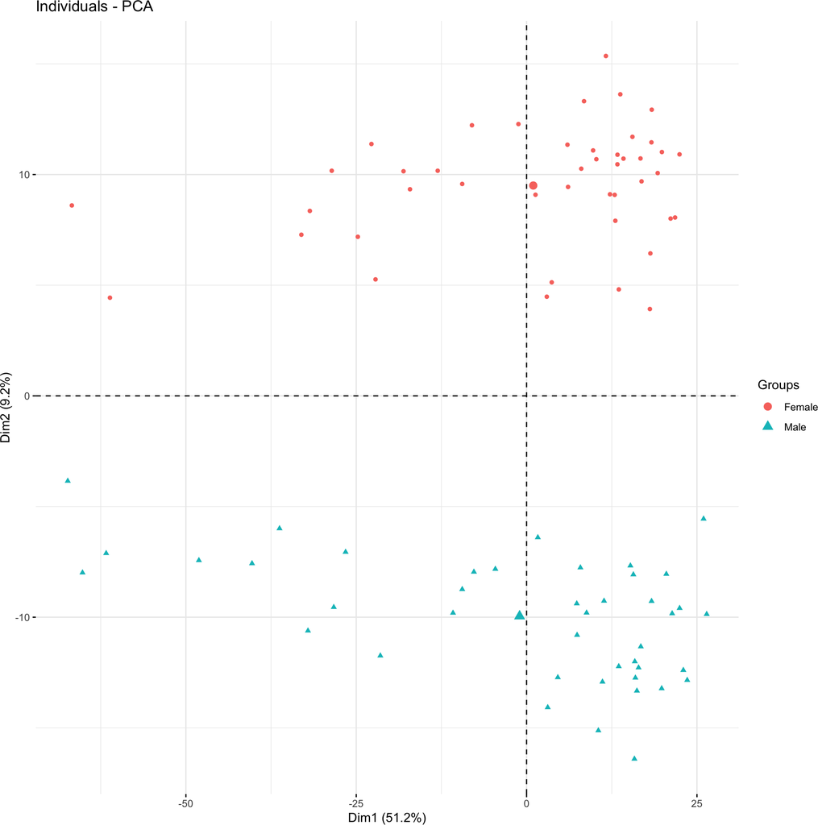

```r
###############################################################################
### Run PCA ###################################################################
###############################################################################

# Define PCA label from metadata
meta_var <- "Gender"

# Run PCA
pca <- metabolitePca(dat,
    meta_var = meta_var
)


# Show PCA
pca
```

Suppose you notice a variable with clearly separated groups that is not a variable of interest. In that case, consider stratifying your downstream analysis by the values of that variable. For example, we will stratify the downstream analysis by male/female in our vignette data.

#### 4.0.2 Heatmaps

For our heatmap, the x-axis will be the samples, and the y-axis will be the metabolites. The values determining the colors will be the log normalized peak values for each metabolite in each observation. We can group the observations by the experimental conditions. Grouping the experimental conditions in a heatmap is another way of visualizing sources of variation within our data.

We can use the metaboliteHeatmap function to create the heatmaps, which requires the following arguments.

- data: SummarizedExperiment with metabolomics experiment data.
- top_mets: The number of metabolites to include in the heatmap. The metabolites are chosen based on the metabolites with the highest variability.
- group_vars: The variables to group the samples by.Note, if you want to order the columns of the heatmap based on a group, you must include them in the group_vars.
- caption: A title for the heatmap. If strat_var is used, the title will automatically include the stratum with the tile.
- Assay: Which assay data to use for the heatmap (default=“normalized”).
- … : You can add additional arguments to order the samples

In the chunk below, we create a PCA plot labeled by Gender. Then, we make three heatmaps increasing by complexity.

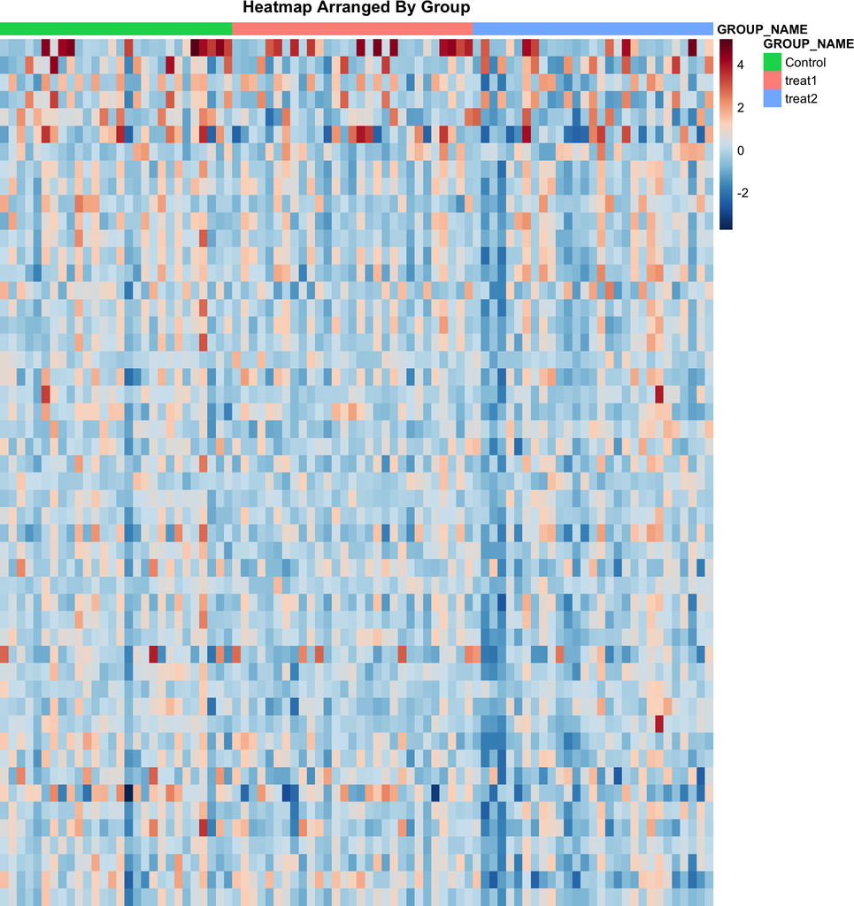

```r
################################################################################
### Run Heatmaps ###############################################################
################################################################################

# Heatmap with one group
metaboliteHeatmap(dat,
    top_mets = 50,
    group_vars = "GROUP_NAME",
    strat_var = NULL,
    caption = "Heatmap Arranged By Group",
    Assay = "normalized",
    GROUP_NAME
)
```

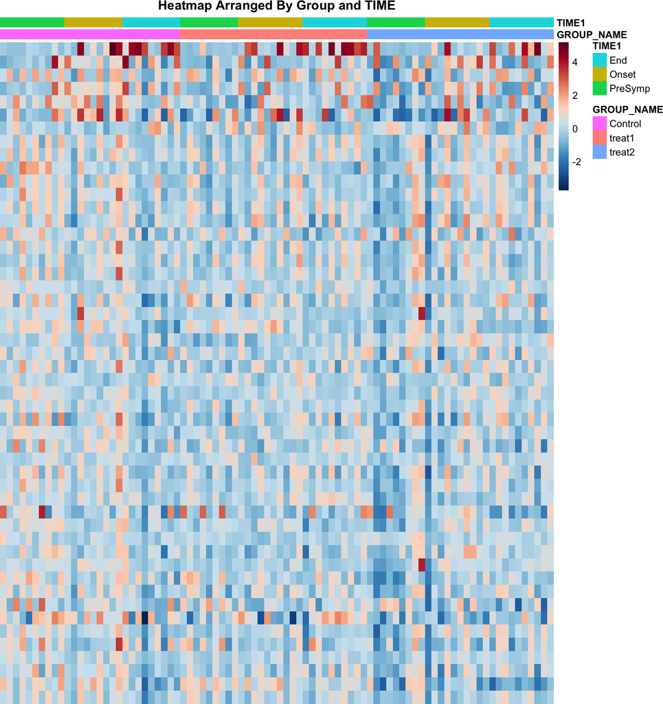

```r
# Heatmap with two groups
metaboliteHeatmap(dat,
    top_mets = 50,
    group_vars = c("GROUP_NAME", "TIME1"),
    strat_var = NULL,
    caption = "Heatmap Arranged By Group and TIME",
    Assay = "normalized",
    GROUP_NAME, desc(TIME1)
)
```

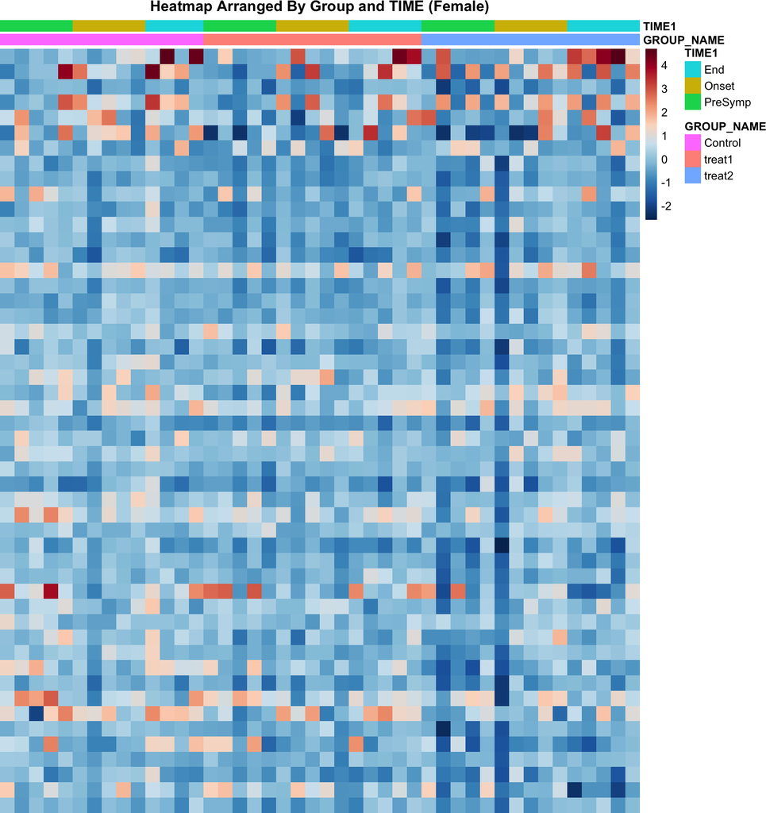

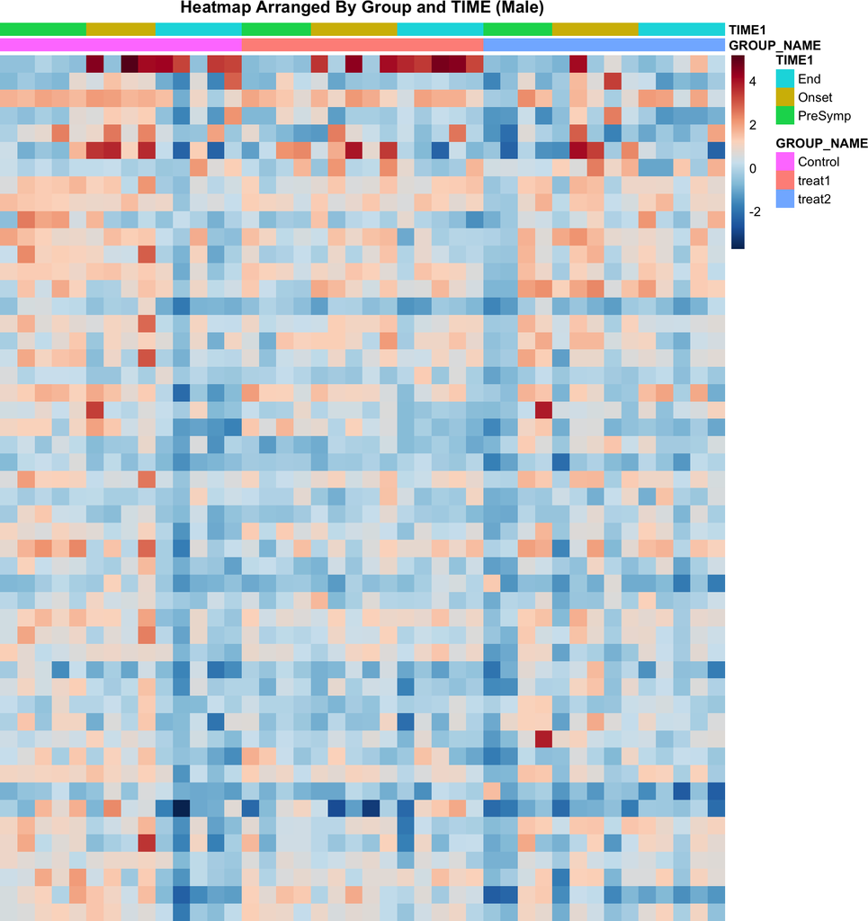

```r
# Heatmap with 2 group and stratified
metaboliteHeatmap(dat,
    top_mets = 50,
    group_vars = c("GROUP_NAME", "TIME1"),
    strat_var = "Gender",
    caption = "Heatmap Arranged By Group and TIME",
    Assay = "normalized",
    GROUP_NAME, desc(TIME1)
)
```

## 5 Subpathway Analysis

In the chemical annotation file, we will see that each metabolite is within a subpathway, and each subpathway is within a superpathway. There are several metabolites within each subpathway and several subpathways within each superpathway. We can utilize an Analysis of variance (ANOVA) model to test for a difference in peak intensities between the treatment groups at the metabolite level. However, since multiple metabolites are within a subpathway, it is challenging to test if the treatment affected the peak data at the subpathway level. For this, we utilize a combined Fisher probability test. The combined Fisher test combines the p-values from independent tests to test the hypothesis for an overall effect. The Combined Fisher Probability is helpful for testing a model at the subpathway level based on the pvalues from the model at the metabolite level.

### 5.1 Combined Fished Analysis

We will test at the subpathway level by combining the p-values for each metabolite within the subpathway for each model. We use a combination function given by $\tilde{X}$ which combines the pvalues, resulting in a chi-squared test statistic.

$$\tilde{X} = -2\sum_{i=1}^k ln(p_i)$$
where $k$ is the number of metabolites in the subpathway. We can get a p-value from $P(X \geq\tilde{X})$, knowing that $\tilde{X}\sim \chi^2_{2k}$. You will notice that smaller p-values will lead to a larger $\tilde{X}$.

##### 5.1.0.1 Assumptions

Since we are first testing each metabolite utilizing ANOVA, we make the following assumptions for each metabolite,

- *Independence:* Each observation is independent of all other observations. Therefore, if you have collected multiple samples from the same subject then this assumption may be violated.
- *Normality:* The metabolite log-scaled intensities follow a normal distribution within each of the treatment groups.
- *Homoscedasticity:* Equal variance between treatment groups.

In addition to the assumptions in the ANOVA models at the metabolite level, the Fisher’s Combined probability places an independence assumption between the metabolites within the subpathway.

For more about the Combined Fisher Probability and other methods that can address this problem, see:

Loughin, Thomas M. “A systematic comparison of methods for combining p-values from independent tests.” Computational statistics & data analysis 47.3 (2004): 467-485.

#### 5.1.1 Models

To test our hypothesis at the subpathway level, we first have to form our hypothesis at the metabolite level. For each metabolite, we test three models.

1.) Interaction: $log Peak = Treatment Group + Time + Treatment*Time$

2.) Parallel: $log Peak = Treatment Group + Time$

3.) Single: $log Peak = Treatment$

For the interaction model, we are focusing only on the interaction term “Treatment*Time” to test if there is a significant interaction between our treatment and the time variable. The parallel model is testing if the time variable is explaining a significant amount of the metabolite variance with treatment included, and the treatment model is testing if the treatment explains a significant proportion of the variance for each metabolite.

We test at the subpathway level using the Combined Fisher Probability method to combine the p-values from each model for all metabolites within the subpathway.

Model selection is based on the combined Fisher p-value. The interaction model is selected if the interaction term in Model 1 is significant. If the blocking factor (TIME1) is significant in Model 2, the parallel model is chosen. If only the treatment term is significant, the single-factor model is selected.

To run the subpathway analysis, we use the “subpathwayAnalysis” function, which requires the following arguments.

- data: SummarizedExperiment with metabolomics experiment data.
- treat_var: This is the name of the variable in the analysis data that is the main variable of interest.
- block_var: This is the name of the blocking variable in the dataset. If the experimental design does not include a blocking variable, then the value of block_var=NULL.
- strat_var: Variable to stratify the subpathway analysis by. This is set to NULL by default and will not stratify the analysis unless specified.
- Assay: Name of the assay to be used for the pairwise analysis (default=‘normalized’)

#### 5.1.2 Results Summaries

With the MetabolomicsPipeline package, we provide three different ways to summarize the results from the subpathway analysis.

1. Number of significant subpathways by model type (subpathByModel)
2. Percentage of significant subpathways within superpathways (subpathWithinSuperpath)
3. Metabolite model results within a specified subpathway (metWithinSub)

**Note:** If any of the ANOVA models above have a warning or an error, the metabolite is excluded and a warning is printed with the message about the warning or error.

```r
################################################################################
## Stratified Analysis #########################################################
################################################################################

# Stratified Analysis
stratified <- subpathwayAnalysis(dat,
    treat_var = "GROUP_NAME",
    block_var = "TIME1",
    strat_var = "Gender",
    Assay = "normalized"
)
```

[output not shown]

```r
################################################################################
### Results Plots ##############################################################
################################################################################

# 1. significant subpathways by model type
subpathByModel(stratified)
```

Table 1: Table 2: Sigificant Pathways by Model

| Model Type | Female | Male |
| --- | --- | --- |
| Interaction | 6 | 84 |
| Parallel | 21 | 12 |
| Single | 19 | 2 |
| None | 64 | 12 |

```r
# 2. Percentage of signficant subpathways within superpathways
subpathWithinSuperpath(stratified)
```

Table 1: Table 1: Proportion of significant subpathways within superpathways

| Super Pathway | Percent Significant (Female) | \|Percent Significant (Male |
| --- | --- | --- |
| Xenobiotics | 5 / 5 (100%) | 5 / 5 (100%) |
| Amino Acid | 13 / 16 (81.25%) | 16 / 16 (100%) |
| Peptide | 3 / 5 (60%) | 3 / 5 (60%) |
| Nucleotide | 3 / 8 (37.5%) | 8 / 8 (100%) |
| Lipid | 17 / 53 (32.08%) | 46 / 53 (86.79%) |
| Carbohydrate | 2 / 8 (25%) | 7 / 8 (87.5%) |
| Cofactors and Vitamins | 2 / 11 (18.18%) | 9 / 11 (81.82%) |
| Energy | 0 / 2 (0%) | 2 / 2 (100%) |
| Partially Characterized Molecules | 0 / 1 (0%) | 1 / 1 (100%) |

```r
# 3. Metabolites within subpathway
tables <- metWithinSub(stratified,
    subpathway = "Partially Characterized Molecules"
)

### Females
tables[[1]]
```

Table 1: Table 1: Metabolites within Partially Characterized Molecules (Female)

| Metabolite Name | Interaction_pval P-Value | Single_pval P-Value |
| --- | --- | --- |
| glutamine_degradant* | 0.488 | 0.285 |
| glucuronide of C14H22O4 (1)* | 0.431 | 0.332 |
| glucuronide of C10H18O2 (11)* | 0.927 | 0.671 |
| glucuronide of C10H18O2 (12)* | 0.996 | 0.390 |
| glycine conjugate of C10H14O2 (1)* | 0.999 | 0.781 |
| pentose acid* | 0.154 | 0.104 |
| branched-chain, straight-chain, or cyclopropyl 10:1 fatty acid (1)* | 0.891 | 0.909 |
| branched-chain, straight-chain, or cyclopropyl 10:1 fatty acid (2)* | 0.962 | 0.999 |
| glycine conjugate of C6H10O2 (2)* | 0.659 | 0.090 |
| glycine conjugate of C6H10O2 (3)* | 0.981 | 0.706 |
| branched-chain, straight-chain, or cyclopropyl 12:1 fatty acid* | 0.899 | 0.717 |
| bilirubin degradation product, C17H18N2O4 (1)** | 0.189 | 0.193 |
| bilirubin degradation product, C17H18N2O4 (2)** | 0.410 | 0.243 |
| bilirubin degradation product, C17H18N2O4 (3)** | 0.591 | 0.261 |
| bilirubin degradation product, C17H20N2O5 (1)** | 0.821 | 0.771 |
| bilirubin degradation product, C17H20N2O5 (2)** | 0.881 | 0.675 |

```r
### Males
tables[[2]]
```

Table 1: Table 1: Metabolites within Partially Characterized Molecules (Male)

| Metabolite Name | Interaction_pval P-Value | Single_pval P-Value |
| --- | --- | --- |
| glutamine_degradant* | 0.100 | 0.844 |
| glucuronide of C14H22O4 (1)* | 0.505 | 0.377 |
| glucuronide of C10H18O2 (11)* | 0.413 | 0.533 |
| glucuronide of C10H18O2 (12)* | 0.013 | 0.837 |
| glycine conjugate of C10H14O2 (1)* | 0.028 | 0.403 |
| pentose acid* | 0.058 | 0.482 |
| branched-chain, straight-chain, or cyclopropyl 10:1 fatty acid (1)* | 0.258 | 0.351 |
| branched-chain, straight-chain, or cyclopropyl 10:1 fatty acid (2)* | 0.045 | 0.161 |
| glycine conjugate of C6H10O2 (2)* | 0.322 | 0.917 |
| glycine conjugate of C6H10O2 (3)* | 0.160 | 0.748 |
| branched-chain, straight-chain, or cyclopropyl 12:1 fatty acid* | 0.015 | 0.001 |
| bilirubin degradation product, C17H18N2O4 (1)** | 0.225 | 0.778 |
| bilirubin degradation product, C17H18N2O4 (2)** | 0.070 | 0.846 |
| bilirubin degradation product, C17H18N2O4 (3)** | 0.031 | 0.647 |
| bilirubin degradation product, C17H20N2O5 (1)** | 0.294 | 0.510 |
| bilirubin degradation product, C17H20N2O5 (2)** | 0.229 | 0.333 |

## 6 Pairwise Analysis

We can look at the pairwise comparisons for all experimental groups at the metabolite level. We will use the metabolite_pairwise function within the MetabolomicsPipeline package, which requires the following arguments:

- data: SummarizedExperiment with metabolomics experiment data.
- Assay: Name of the assay to be used for the pairwise analysis (default=‘normalized’)
- mets: Chemical ID for the metabolites of interest. If NULL then the pairwise analysis is completed for all metabololites.
- form: This is a character string the resembles the right hand side of a simple linear regression model in R. For example form = “Group1 + Group2”.
- strat_var: A variable in the analysis data to stratify the model by. If this is specified, a list of results will be returned.

#### 6.0.1 Log Fold-Change Heatmap

We will produce a heatmap of the log fold changes for the metabolites with a significant overall p-value (which tested if the treatment group means were equal under the null hypothesis). The heatmap colors will only show if the log fold-change is greater than log(2) or less than log(.5). Therefore, this heatmap will only focus on comparisons with a fold change of two or greater. The met_est_heatmap function will produce an interactive heatmap using the results from the pairwise analysis.

#### 6.0.2 P-Value Heatmap

Similar to the pairwise estimate heatmap, we will produce a heatmap where the heatmap will only include metabolites with a significant overall p-value, and the values in the heat map will only be colored if the pairwise comparison is significant. We use the metPHeatmap function to create an interactive p-value heatmap.

For both the log fold-change heatmap and the p-value heatmap, there is an option to produce an interactive plot using plotly or to create a static heatmap using pheatmap. To produce these heatmaps we use the following arguments:

- results_data: Results data frame of the pairwise comparisons produced by .
- data: A SummarizedExperiment containing the metabolomics experiment data.
- FC_cutoff: Numeric value for the fold change cutoff. Must be larger than 1. Default is 2.
- pv_cutoff: Numeric value for the p-value cutoff. Default is 0.05.
- interactive: boolean (TRUE/FALSE) for whether or not the plot should be interactive. Use interactive=T to produce an interactive plot using plotly. Use interactive=FALSE to produce a static heatmap using pheatmap.
- plotlyTitle: Title for the interactive heatmap
- …: Additional arguments that can be passed to pheatmap. This is only for the static heatmap.

```r
################################################################################
#### Run Pairwise Comparisons ##################################################
################################################################################

strat_pairwise <- metabolitePairwise(dat,
    form = "GROUP_NAME*TIME1",
    strat_var = "Gender"
)
```

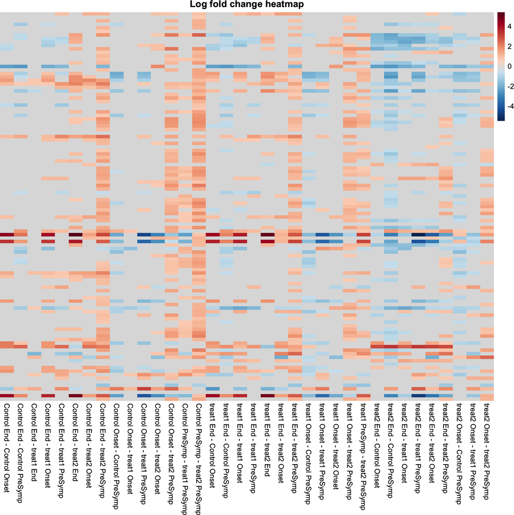

```r
###############################################################################
## Create Estimate Heatmap #####################################################
################################################################################

metEstHeatmap(strat_pairwise$Female, dat,
    interactive = FALSE,
     SUB_PATHWAY = "SUB_PATHWAY",
    CHEMICAL_NAME = "CHEMICAL_NAME",
    plotlyTitle = "Estimate Heatmap",
    main = "Log fold change heatmap", show_rownames = FALSE
)
```

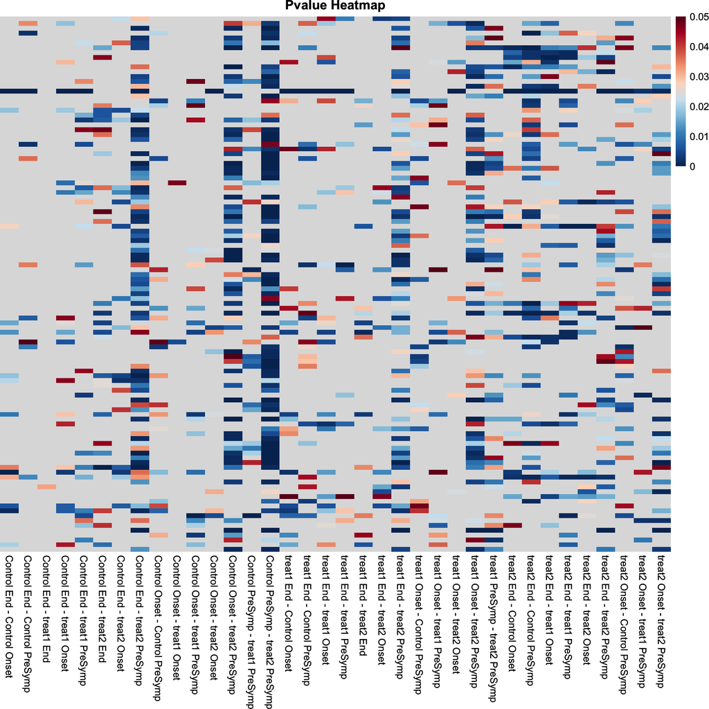

```r
################################################################################
## Create P-value Heatmap ######################################################
################################################################################
# Female
metPHeatmap(strat_pairwise$Female, dat,
    interactive = FALSE, show_rownames = FALSE,
    plotlyTitle = "Pvalue Heatmap",
    main = "Pvalue Heatmap"
)
```

## 7 Boxplots and Lineplots

Visualizations of the data can help us see the underlying trends. Two useful visualizations are boxplots and line plots, we will be using the subpathwayBoxplots and subpathwayLineplots functions to create them. The main utility of these functions is it allows you for focus on the metabolites within a subpathway. For both functions, the arguments are:

- data: SummarizedExperiment with metabolomics experiment data.
- subpathway: Character value of the subpathway of interest. This is case sensitive and must be in the chemical annotation file.
- block_var: This the the name of the variable in the meta data that is used for the X axis of the box plots. We recommend using the “block_var” from the subpathway analysis.
- treat_var: This is a grouping variable. As a recommendation the treatment groups should be used in the treat_var argument as this will provide a different color for each of the treatments making it easier to identify.
- Assay: Name of the assay to be used for the pairwise analysis (default=‘normalized’)
- … : Additional arguments to filter the analysis data by.

#### 7.0.1 Boxplots and Lineplots steps

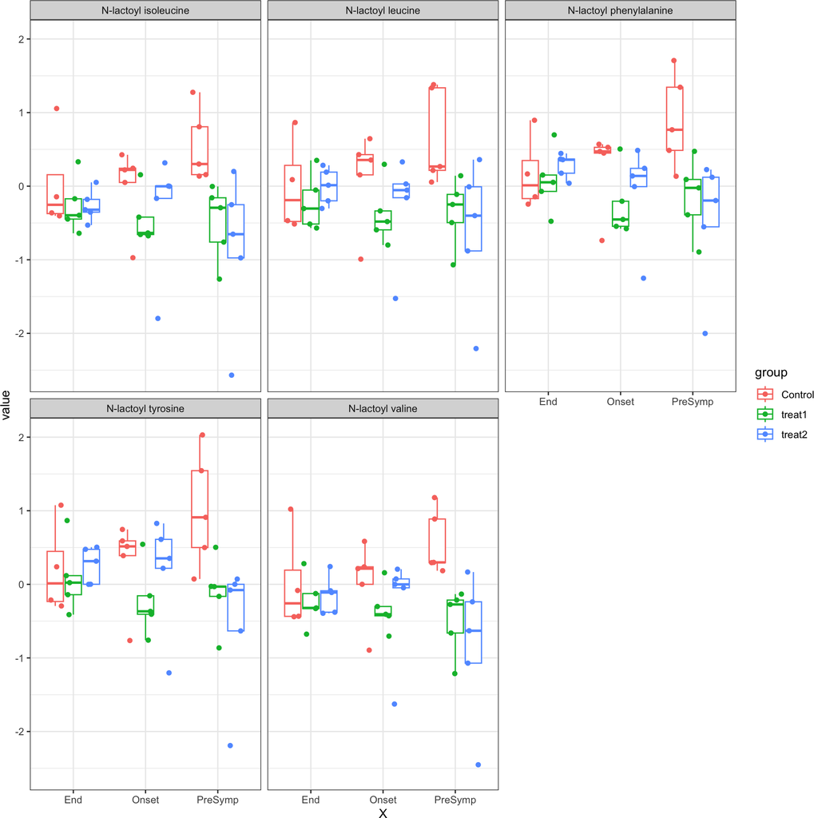

```r
################################################################################
### BoxPlots ###################################################################
################################################################################

subpathwayBoxplots(dat,
    subpathway = "Lactoyl Amino Acid", block_var = TIME1,
    treat_var = GROUP_NAME, Assay = "normalized",
    CHEMICAL_NAME = "CHEMICAL_NAME",
   SUB_PATHWAY = "SUB_PATHWAY", Gender == "Female"
)
```

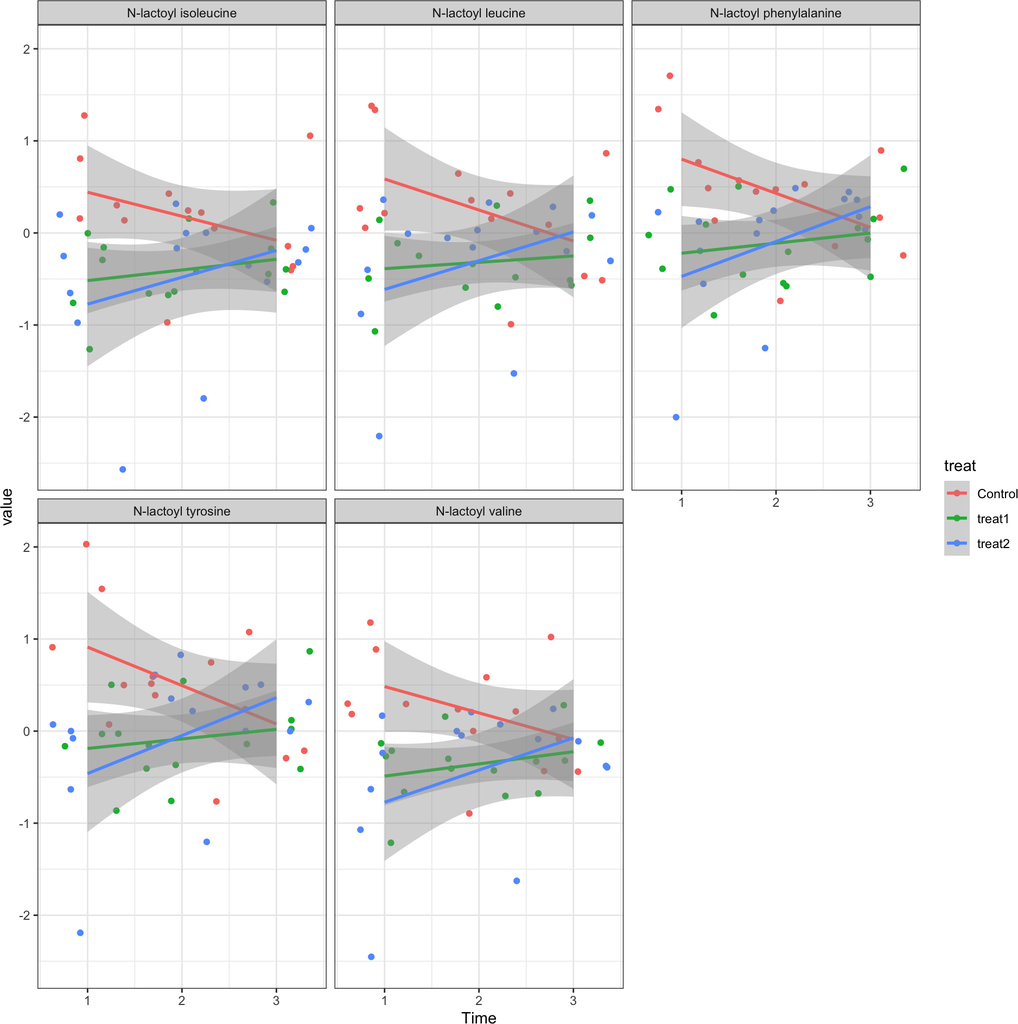

```r
################################################################################
## Line plots ##################################################################
################################################################################

# Set up data
dat$TIME1 <- as.numeric(factor(dat$TIME1,
    levels = c("PreSymp", "Onset", "End")
))

# Create line plots
subpathwayLineplots(dat,
    subpathway = "Lactoyl Amino Acid",
    block_var = TIME1, treat_var = GROUP_NAME,
    Assay = "normalized",
    CHEMICAL_NAME = "CHEMICAL_NAME",
   SUB_PATHWAY = "SUB_PATHWAY", Gender == "Female"
) +
    xlab("Time")
```